5/6/2020

## 10.1

There is a trade-off between predictive and interpretablility

- more predictors than number of samples (p>>n)
- models are complex

## 10.1

Motivation

- mitigate specific problem in the interplay between predictors and a model
  - SVM, neural networks are sensitive to irrelevant predictors
  - linear or logistic are vulnerable to correlated predictors
- reduce complexity
  - reduce cost of acquiring data
  - improve throughput

## 10.2

three general classes:

- intrinsic methods
  - tree and rule based models
  - MAR models?
  - regularization models
- advantages
  - relatively fast
  - no external feature selection tool needed
  - objective function = statistic need to optimize
- downside
  - model dependent
  - greedy, identify a narrow set of features

## 10.2

three general classes:

- filter methods
  - supervised analysis of the predictors
  - one time
  - consider each predictor separately
- advantages
  - simple and fast
  - effective at capturing large trends
- downside
  - disconnect betwen the objective function for the filter and predictive performance

## 10.2

- wrapper methods
  - iterative search
  - greedy (recursive feature elimination RFE)
  - non-greedy (genetic algorithms, simulated annealing)
- advantages
  - wider variety of predictor subsets
- downside
  - computational expensive
  - potential to overfit

## 10.2

summary:

- start with one or more intrinsic methods
- if start with non-linear intrinsic
  - proceed with a wrapper method that is combined with a non-linear model
- if start with a linear intrinsic
  - proceed with a wrapper combined with a linear model

## 10.3

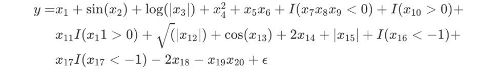

## 10.3

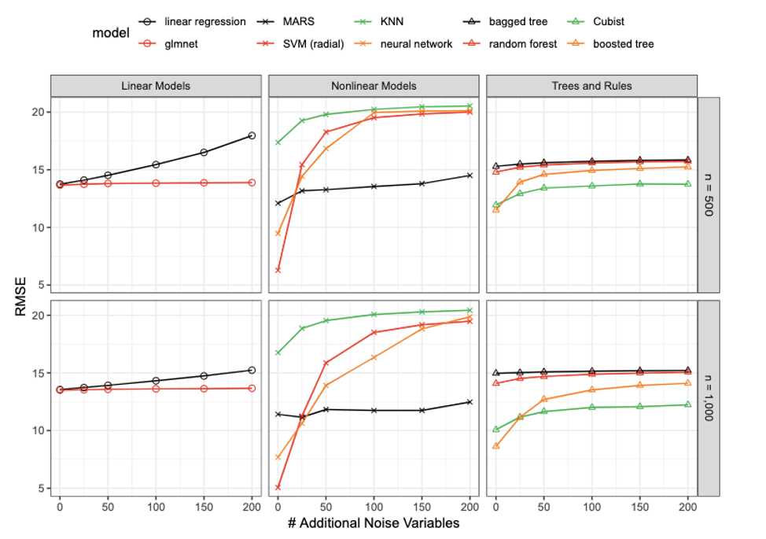

## 10.3

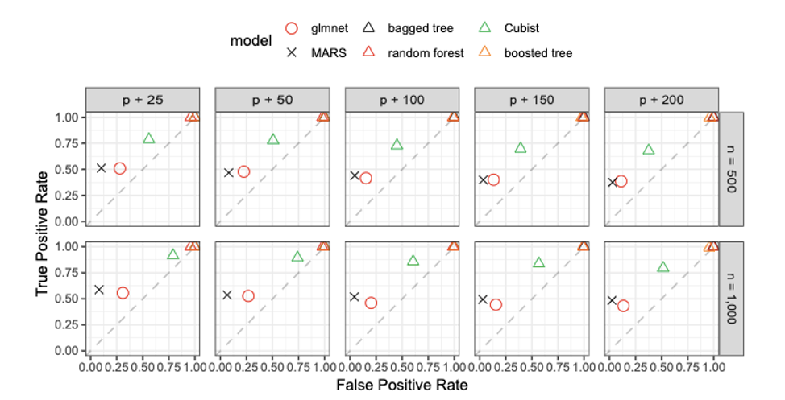

## 10.4

overfitting to predictors and external validation

solution

- evaluate the tuning parameters using different data set
- feature selection needs to be part of the resampling process

## 10.4

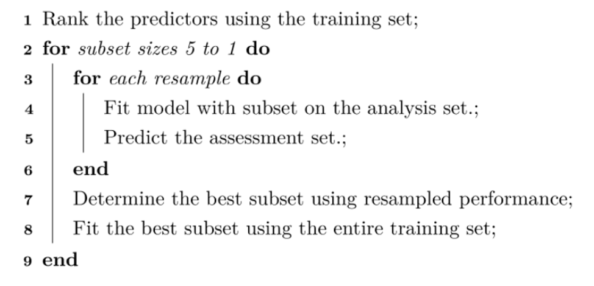

## 10.4

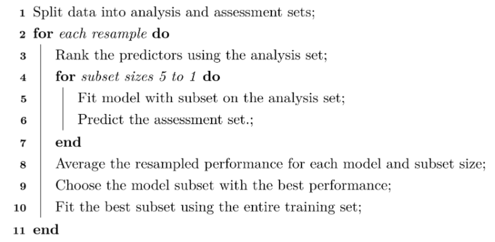

## 10.5

case study

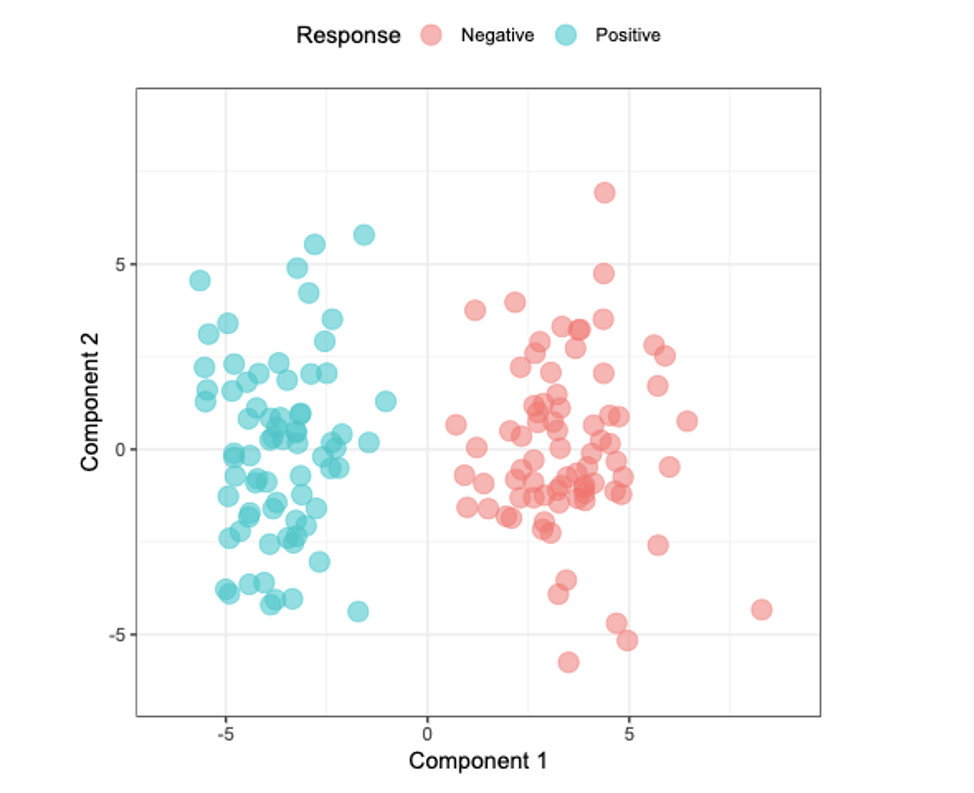